# Foil task - Capuchins - Markdown

December 09, 2018

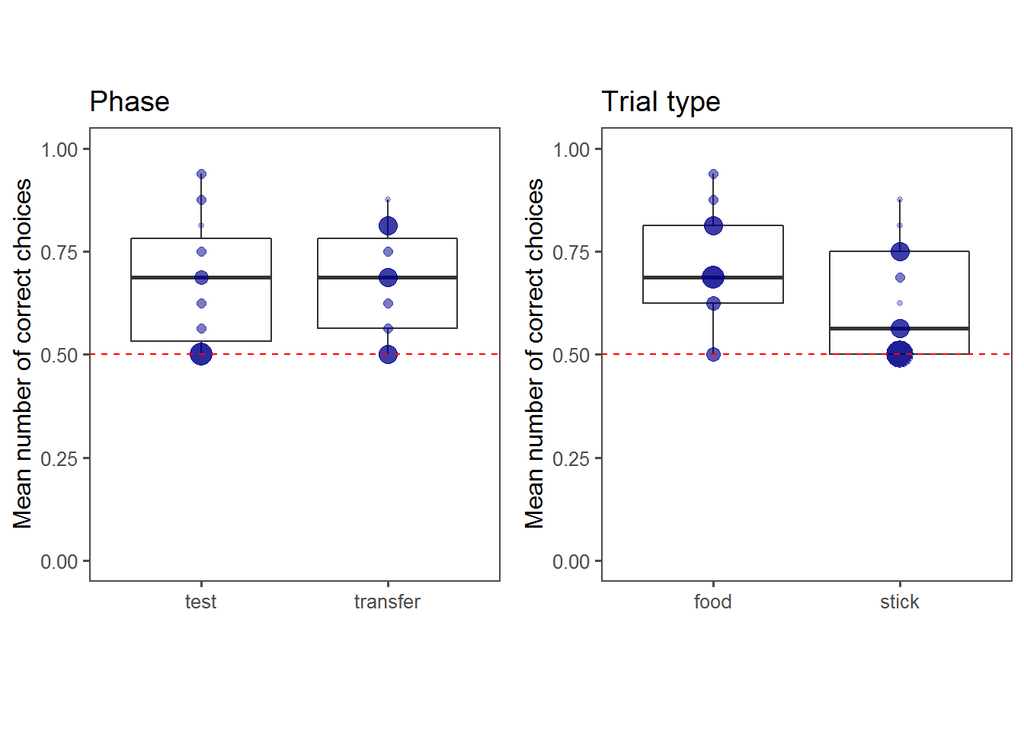

- Dashed line: chance level

## Test against chance

#### Test and transfer phase

- Mean correct vs chance value (0.5) in **Test phase**: Mean = 0.68, 95% CI [0.6, 0.75], *t*(18)=5, *p*=0
- Mean correct vs chance value (0.5) in **Transfer phase**: Mean = 0.67, 95% CI [0.61, 0.73], *t*(18)=5.98, *p*=0

##### Comparison between test and transfer phase

- Difference between test and transfer phase: Mean difference = 0.01, 95% CI [-0.08, 0.09], *t*(18)=0.17, *p*=0.869
- Bayes Factor for the Null Hypothesis (Difference between test and transfer = 0):

```
## Bayes factor analysis
## --------------
## [1] Null, mu=0 : 4.157993 ±0.02%
##
## Against denominator:
##   Alternative, r = 0.707106781186548, mu =/= 0
## ---
## Bayes factor type: BFoneSample, JZS
```

–> Evidence for no difference between test and transfer performance.

#### Trial type

- Mean correct vs chance value (0.5) in **Stick trials**: Mean = 0.63, 95% CI [0.57, 0.69], *t*(18)=4.51, *p*=0
- Mean correct vs chance value (0.5) in **Food trials**: Mean = 0.72, 95% CI [0.65, 0.79], *t*(18)=6.85, *p*=0

##### Comparison between stick and food trials

- Difference between food and stick trials: Mean difference = 0.09, 95% CI [0.02, 0.16], *t*(18)=2.8, *p*=0.012

## GLMM

### Preprocessing of the data

- Relevel trial type reference category: “stick” as reference category
- Scale variables: trial number and age
- Centering of random slope components of categorical predictors (trial type and phase)

#### Full model

```r
glmm01_full=glmer(correct ~ trialtype*phase+z.trialno+z.age+sex+
             (1+z.trialno+phase.transfer.c+trialtype.food.c|id)+(1|boxtype),
           data=ripmon1, family=binomial, control=contr)
```

#### Null model

- Full-null model comparison

```
## Data: ripmon1
## Models:
## glmm01_null: correct ~ 1 + (1 + z.trialno + phase.transfer.c + trialtype.food.c |
## glmm01_null:     id) + (1 | boxtype)
## glmm01_full: correct ~ trialtype * phase + z.trialno + z.age + sex + (1 +
## glmm01_full:     z.trialno + phase.transfer.c + trialtype.food.c | id) + (1 |
## glmm01_full:     boxtype)
##             Df    AIC    BIC  logLik deviance Chisq Chi Df Pr(>Chisq)
## glmm01_null 12 785.29 838.21 -380.64   761.29
## glmm01_full 18 783.50 862.88 -373.75   747.50 13.79      6      0.032 *
## ---
## Signif. codes:  0 '***' 0.001 '**' 0.01 '*' 0.05 '.' 0.1 ' ' 1
```

##### Model output

- Coefficients

```
##                             Estimate Std. Error z value Pr(>|z|)
## (Intercept)                    0.175      0.252   0.695    0.487
## trialtypefood                  0.441      0.318   1.386    0.166
## phasetransfer                 -0.088      0.256  -0.345    0.730
## z.trialno                     -0.019      0.091  -0.209    0.834
## z.age                         -0.147      0.105  -1.395    0.163
## sexm                           0.594      0.225   2.646    0.008
## trialtypefood:phasetransfer    0.051      0.437   0.117    0.907
```

- Individual predictors: likelihood ratio tests  
  Drop1: P values for the individual effects were based on likelihood ratio tests comparing the full with respective reduced models (Barr et al., 2013; R function drop1 with argument ‘test’ set to “Chisq”).

```
## Single term deletions
##
## Model:
## correct ~ trialtype * phase + z.trialno + z.age + sex + (1 +
##     z.trialno + phase.transfer.c + trialtype.food.c | id) + (1 |
##     boxtype)
##                 Df    AIC   LRT Pr(Chi)
## <none>             783.50
## z.trialno        1 781.54 0.044   0.834
## z.age            1 783.48 1.983   0.159
## sex              1 787.61 6.115   0.013 *
## trialtype:phase  1 781.51 0.014   0.907
## ---
## Signif. codes:  0 '***' 0.001 '**' 0.01 '*' 0.05 '.' 0.1 ' ' 1
```

### Reduced model without interactions

#### Full model

```r
glmm02_full=glmer(correct ~ trialtype+phase+z.trialno+z.age+sex+
             (1+z.trialno+phase.transfer.c+trialtype.food.c|id)+(1|boxtype),
           data=ripmon1, family=binomial, control=contr)
```

Note: removed the interaction between random slope components due to convergence issues for likelihood ratio tests (drop1).

#### Null model

Full-null model comparison

```
## Data: ripmon1
## Models:
## glmm02_null: correct ~ 1 + (1 + z.trialno + phase.transfer.c + trialtype.food.c |
## glmm02_null:     id) + (1 | boxtype)
## glmm02_full: correct ~ trialtype + phase + z.trialno + z.age + sex + (1 +
## glmm02_full:     z.trialno + phase.transfer.c + trialtype.food.c | id) + (1 |
## glmm02_full:     boxtype)
##             Df    AIC    BIC  logLik deviance  Chisq Chi Df Pr(>Chisq)
## glmm02_null 12 785.29 838.21 -380.64   761.29
## glmm02_full 17 781.51 856.49 -373.76   747.51 13.776      5      0.017 *
## ---
## Signif. codes:  0 '***' 0.001 '**' 0.01 '*' 0.05 '.' 0.1 ' ' 1
```

##### Model output

- Coefficients

```
##               Estimate Std. Error z value Pr(>|z|)
## (Intercept)      0.160      0.216   0.741    0.459
## trialtypefood    0.470      0.198   2.376    0.017
## phasetransfer   -0.069      0.193  -0.357    0.721
## z.trialno       -0.019      0.091  -0.210    0.834
## z.age           -0.146      0.105  -1.390    0.165
## sexm             0.601      0.219   2.748    0.006
```

- Individual predictors: likelihood ratio tests  
  Drop1: P values for the individual effects were based on likelihood ratio tests comparing the full with respective reduced models (Barr et al., 2013; R function drop1 with argument ‘test’ set to “Chisq”).

```
## Single term deletions
##
## Model:
## correct ~ trialtype + phase + z.trialno + z.age + sex + (1 +
##     z.trialno + phase.transfer.c + trialtype.food.c | id) + (1 |
##     boxtype)
##           Df    AIC   LRT Pr(Chi)
## <none>       781.51
## trialtype  1 785.07 5.560   0.018 *
## phase      1 779.64 0.128   0.720
## z.trialno  1 779.56 0.044   0.834
## z.age      1 781.48 1.970   0.160
## sex        1 786.02 6.511   0.011 *
## ---
## Signif. codes:  0 '***' 0.001 '**' 0.01 '*' 0.05 '.' 0.1 ' ' 1
```

##### Plot random effects

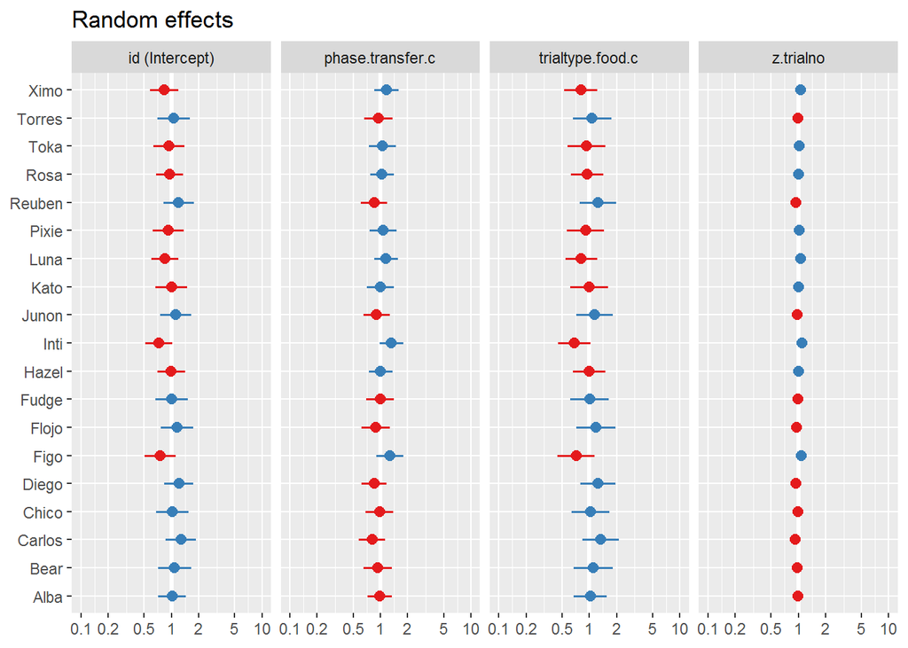

##### Plot predictors

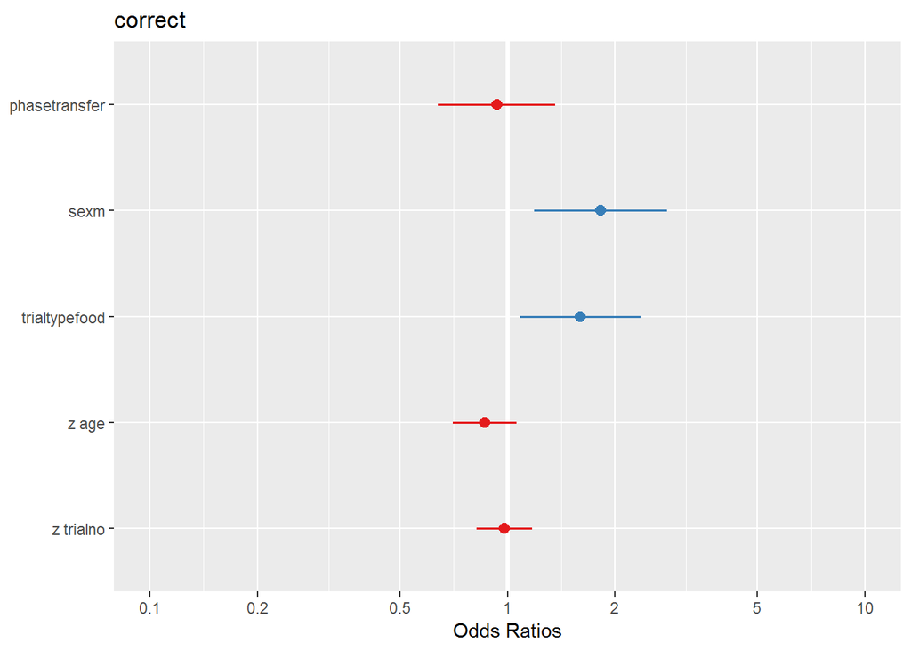

##### Check for model stability

Check for model stability by removing levels of the random effects on by one and visualising the resulting variance of each variable

```
## [1] "please carefully evaluate whether the result makes sense, and if not, please contact me"
```

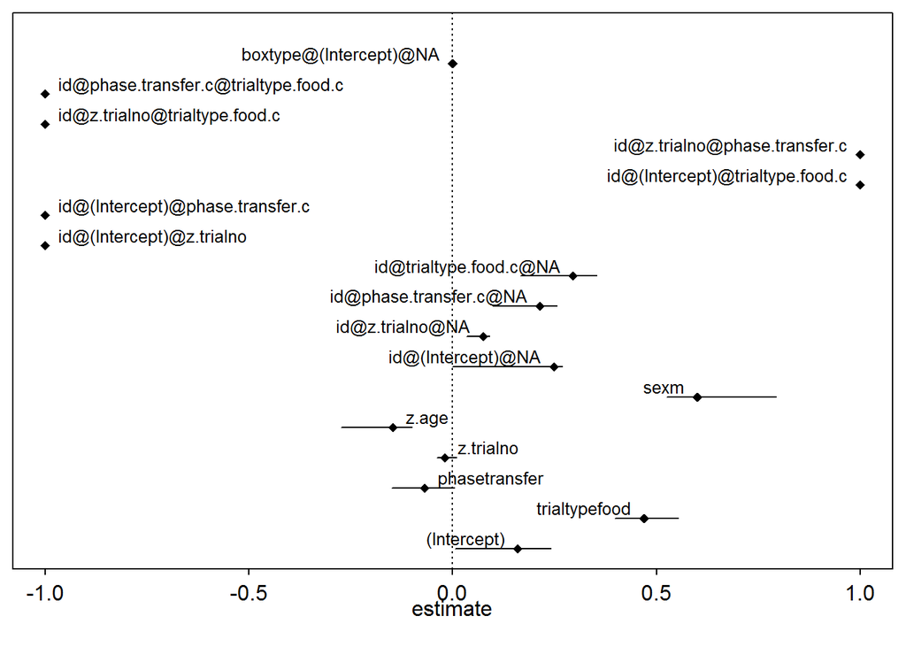

##### Check for multicollinearity

```
## trialtype     phase z.trialno     z.age       sex
##     1.003     1.003     1.000     1.030     1.030
```

–> no colinearity issues.